# Analyzing WGBS data with bsseq

2022-11-24

# Analyzing WGBS data with bsseq

Kasper Daniel Hansen

1 November 2022

# Abstract

An informal guide to analyzing WGBS using bsseq. (WGBS) datta.

Package

bsseq 1.34.0

# 1 Introduction

This document discusses the ins and outs of an analysis of a whole-genome shotgun bisulfite sequencing (WGBS) dataset, using the BSmooth algorithm, which was first used in (Hansen et al. 2011) and more formally presented and evaluated in (Hansen, Langmead, and Irizarry 2012). The intention with the document is to focus on analysis-related tasks and questions. Basic usage of the bsseq package is covered in “The bsseq user’s guide”. It may be useful to consult the user’s guide while reading this analysis guide.

In this vignette we analyze chromosome 21 and 22 from (Hansen et al. 2011). This is primary data from 3 patients with colon cancer. For each patient we have normal colon tissue as well as cancer colon. The samples were run on ABI SOLiD and we generated 50bp single-end reads. The reads were aligned using the Merman aligner in the BSmooth suite . See the primary publication for more details (Hansen et al. 2011).

This data is contained in the bsseqData

```r
library(bsseq)
library(bsseqData)
```

The bsseqData contains a script, `inst/script/create\_BS.cancer.R`, describing how this data is created from the Merman alignment output (also contained in the package). Note that the current version of the BSmooth pipeline uses a slightly different alignment output format.

The following object contains the unsmoothed “raw” summarized alignment data.

```r
data(BS.cancer.ex)
BS.cancer.ex <- updateObject(BS.cancer.ex)
BS.cancer.ex
```

```
## An object of type 'BSseq' with
##   958541 methylation loci
##   6 samples
## has not been smoothed
## All assays are in-memory
```

```r
pData(BS.cancer.ex)
```

```
## DataFrame with 6 rows and 2 columns
##           Type        Pair
##    <character> <character>
## C1      cancer       pair1
## C2      cancer       pair2
## C3      cancer       pair3
## N1      normal       pair1
## N2      normal       pair2
## N3      normal       pair3
```

If you use this package, please cite our BSmooth paper (Hansen, Langmead, and Irizarry 2012).

# 2 Smoothing

The first step of the analysis is to smooth the data

```r
BS.cancer.ex.fit <- BSmooth(
    BSseq = BS.cancer.ex,
    # BPPARAM = MulticoreParam(workers = 1),
    verbose = TRUE)
```

This particular piece of code is not being run when the vignette is being created. It takes roughly 2 minutes per sample. If you have 6 cores available, use `mc.cores = 6` and the total run time will be roughly 2 minutes. Note that setting mc.cores to a value greater than 1 is not support on MS Windows due to a limitation of the operating system.

For ease of use, the bsseqData includes the result of this command:

```r
data(BS.cancer.ex.fit)
BS.cancer.ex.fit <- updateObject(BS.cancer.ex.fit)
BS.cancer.ex.fit
```

```
## An object of type 'BSseq' with
##   958541 methylation loci
##   6 samples
## has been smoothed with
##   BSmooth (ns = 70, h = 1000, maxGap = 100000000)
## All assays are in-memory
```

This step uses parallelization where each sample is run on a separate core using `mclapply()` from the parallel package. This form of parallelization is built into bsseq, and (as written) requires access to a machine with 6 cores and enough RAM. The smoothing step is being done completely independently on each sample, so if you have a lot of samples (or other circumstances), an alternative is to split the computations manually. A later subsection shows some example code for doing that.

Let us discuss coverage and representation. The BS.cancer.ex object contains all annotated CpGs on human chromosome 21 and 22, whether or not there is actual data. Since we have multiple samples, we can roughly divide the genome into 3 categories: CpGs where all samples have data, CpGs where none of the samples have data and CpGs where some, but not all, of the samples have data. Examining the object at hand, we get

```r
## The average coverage of CpGs on the two chromosomes
round(colMeans(getCoverage(BS.cancer.ex)), 1)
```

```
##  C1  C2  C3  N1  N2  N3
## 3.5 4.2 3.7 4.0 4.3 3.9
```

```r
## Number of CpGs in two chromosomes
length(BS.cancer.ex)
```

```
## [1] 958541
```

```r
## Number of CpGs which are covered by at least 1 read in all 6 samples
sum(rowSums(getCoverage(BS.cancer.ex) >= 1) == 6)
```

```
## [1] 572628
```

```r
## Number of CpGs with 0 coverage in all samples
sum(rowSums(getCoverage(BS.cancer.ex)) == 0)
```

```
## [1] 136019
```

The CpG coverage is roughly 4x, so we would expect many zero coverage CpGs by chance. although that should not necessarily occur in all 6 samples at the same CpG. If we assume that coverage genome-wide is Poisson distributed with a parameter (lambda) of 4, we would expect

```r
logp <- ppois(0, lambda = 4, lower.tail = FALSE, log.p = TRUE)
round(1 - exp(6 * logp), 3)
```

```
## [1] 0.105
```

of the CpGs to have at least one sample with zero coverage.

There are roughly 130k CpGs with no data at all in any of the 6 samples. This can happen either because of chance (although that is unlikely) or because the CpG is unmappable. Since we are dealing with bisulfite converted reads, the unmappable portion of the genome is greater than with normal DNA-sequencing. For this experiment we only used 50bp single-end reads (in our experience using 100bp paired-end reads greatly increases the mappable percentage of the genome). These CpGs (with zero coverage in all samples) are in some sense easy to deal with: one should of course be careful drawing conclusions about CpGs with no data.

We have roughly 959 - 573 - 136 = 250$ CpGs where some (but not all) of the samples have zero coverage, and these are in some sense harder to deal with. Since we have very low coverage to begin with, it may happen just by chance that a single sample have zero coverage, and it may be too restrictive to just exclude these CpGs from an analysis.

Smoothing is done separately for each sample, only using the data where the coverage (for that sample) is non-zero. This estimates a genome-wide methylation profile, which is then evaluated in all CpGs in the BSseq object. As a result, after smoothing, every CpG in the object has an estimated methylation value. This is very nice for the situation where you want to compare a single CpG across multiple samples, but one or two of the samples have zero coverage by chance. But note that these smoothed methylation profiles makes less sense in the parts of the genome where there are no covered CpGs nearby. We fix this by removing these CpGs after smoothing, see below.

Other arguments to the `BSmooth()` function are mc.cores, mc.preschedule, parallelBy which controls the parallelization built into the function as well as ns, h, maxGap which controls the smoothing. ns is the minimum number of CpGs contained in each window, h is half the minimum window with (the actual window width is either 2 times h or wide enough to contain ns covered CpGs, whichever is greater). Note that the window width is different at each position in the genome and may also be different for different samples at the same position, since it depends on how many nearby CpGs with non-zero coverage. Per default, a smoothing cluster is a whole chromosome. By “cluster” we mean a set of CpGs which are processed together. This means that even if there is a large distance between two CpGs, we borrow strength between them. By setting maxGap this can be prevented since the argument describes the longest distance between two CpGs before a cluster is broken up into two clusters.

## 2.1 Manually splitting the smoothing computation

An example, only showing sample 1 and 2 for brevity, is (this example is not being run when the vignette is being created):

```r
# ## Split datag
# BS1 <- BS.cancer.ex[, 1]
# save(BS1, file = "BS1.rda")
# BS2 <- BS.cancer.ex[, 2]
# save(BS2, file = "BS2.rda")
# ## done splitting
# ## Do the following on each node
#
# ## node 1
# load("BS1.rda")
# BS1.fit <- BSmooth(BS1)
# save(BS1.fit, file = "BS1.fit.rda")
# ## done node 1
#
# ## node 2
# load("BS2.rda")
# BS2.fit <- BSmooth(BS2)
# save(BS2.fit, file = "BS2.fit.rda")
# ## done node 2
#
# ## join; in a new R session
# load("BS1.fit.rda")
# load("BS2.fit.rda")
# BS.fit <- combine(BS1.fit, BS2.fit)
# # Error in SimpleList(coef = ans_coef) : object 'ans_coef' not found
```

This still requires that you have one node with enough RAM to hold all samples in memory.

# 3 Computing t-statistics

Before computing t-statistics, we will remove CpGs with little or no coverage. If this is not done, you may find many DMRs in areas of the genome with very little coverage, which are most likely false positives. It is open to personal preferences exactly which CpGs to remove, but for this analysis we will only keep CpGs where at least 2 cancer samples and at least 2 normal samples have at least 2x in coverage. For readability, we store the coverage in a separate matrix (this is just due to line breaks in the printed output).

```r
BS.cov <- getCoverage(BS.cancer.ex.fit)
keepLoci.ex <- which(rowSums(BS.cov[, BS.cancer.ex$Type == "cancer"] >= 2) >= 2 &
                     rowSums(BS.cov[, BS.cancer.ex$Type == "normal"] >= 2) >= 2)
length(keepLoci.ex)
```

```
## [1] 597371
```

```r
BS.cancer.ex.fit <- BS.cancer.ex.fit[keepLoci.ex,]
```

(the keepLoci.ex is also available for direct inspection in the bsseqData package.)

We are now ready to compute t-statistics, by

```r
BS.cancer.ex.tstat <- BSmooth.tstat(BS.cancer.ex.fit,
                                    group1 = c("C1", "C2", "C3"),
                                    group2 = c("N1", "N2", "N3"),
                                    estimate.var = "group2",
                                    local.correct = TRUE,
                                    verbose = TRUE)
```

```
## [BSmooth.tstat] preprocessing ... done in 0.3 sec
## [BSmooth.tstat] computing stats within groups ... done in 0.2 sec
## [BSmooth.tstat] computing stats across groups ... done in 0.7 sec
```

```r
BS.cancer.ex.tstat
```

```
## An object of type 'BSseqTstat' with
##   597371 methylation loci
## based on smoothed data:
##   BSmooth (ns = 70, h = 1000, maxGap = 100000000)
## with parameters
##   BSmooth.tstat (local.correct = TRUE, maxGap = 100000000)
```

(the BS.cancer.ex.tstat is also available for direct inspection in the bsseqData package.)

The arguments to BSmooth.tstat() are simple. group1 and group2 contain the sample names of the two groups being compared (it is always group1 - group2), and indices may be used instead of sample names. estimate.var describes which samples are being used to estimate the variability. Because this is a cancer dataset, and cancer have higher variability than normals, we only use the normal samples to estimate the variability. Other choices of estimate.var are same (assume same variability in each group) and paired (do a paired t-test). The argument local.correct describes whether we should use a large-scale (low-frequency) mean correction. This is especially important in cancer where we have found many large-scale methylation differences between cancer and normals.

We can look at the marginal distribution of the t-statistic by

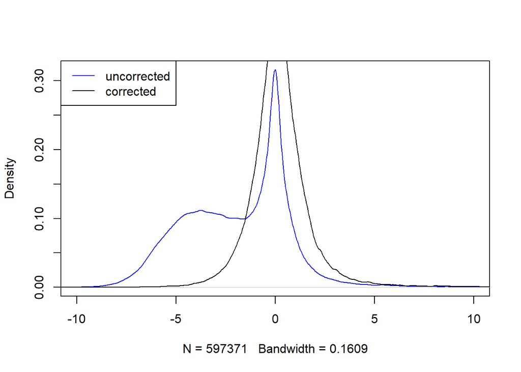

```r
plot(BS.cancer.ex.tstat)
```

The “blocks” of hypomethylation are clearly visible in the marginal distribution of the uncorrected t-statistics.

Even in comparisons where we do not observe these large-scale methylation differences, it often improves the marginal distribution of the t-statistics to locally correct them (“improves” in the sense of making them more symmetric).

# 4 Finding DMRs

Once t-statistics have been computed, we can compute differentially methylated regions (DMRs) by thresholding the t-statistics. Here we use a cutoff of 4.6, which was chosen by looking at the quantiles of the t-statistics (for the entire genome).

```r
dmrs0 <- dmrFinder(BS.cancer.ex.tstat, cutoff = c(-4.6, 4.6))
```

```
## [dmrFinder] creating dmr data.frame
```

```r
## [dmrFinder] creating dmr data.frame
dmrs <- subset(dmrs0, n >= 3 & abs(meanDiff) >= 0.1)
nrow(dmrs)
```

```
## [1] 373
```

```r
head(dmrs, n = 3)
```

```
##      chr    start      end idxStart idxEnd cluster   n width invdensity
## 14 chr21 28215373 28219673    57140  57375   15140 236  4301   18.22458
## 21 chr21 32929738 32932526    79950  80169   20172 220  2789   12.67727
## 26 chr21 34441912 34444680    92256  92480   21568 225  2769   12.30667
##    areaStat  maxStat  meanDiff group1.mean group2.mean   tstat.sd direction
## 14 2623.165 13.50173 0.3423310   0.3870996  0.04476853 0.04503204     hyper
## 21 2326.016 12.16182 0.3616328   0.4174597  0.05582693 0.04492697     hyper
## 26 2156.520 12.39799 0.3093227   0.3406376  0.03131488 0.04604162     hyper
```

Here, we filter out DMRs that do not have at least 3 CpGs in them and at least a mean difference (across the DMR) in methylation between normal and cancers of at least 0.1. While the exact values of these two filters can be debated, it is surely a good idea to use something like this.

Other arguments to `dmrFinder()` are qcutoff which chooses a quantile-based cutoff (for example qcutoff = c(0.01, 0.99)) and maxGap which makes sure that a DMR is being split if there are two CpGs with more than maxGap between them (default of 300bp).

We rank DMRs by the column areaStat which is the sum of the t-statistics in each CpG. This is kind of the area of the DMR, except that it is weighted by the number of CpGs and not by genomic length. This is currently the best statistic we know, although it is far from perfect (we would like to do something better).

# 5 Plotting

It is always a good idea to look at the DMRs. One way of encoding standard plotting parameters like col, lty, and lwd is to add columns to the pData, like

```r
pData <- pData(BS.cancer.ex.fit)
pData$col <- rep(c("red", "blue"), each = 3)
pData(BS.cancer.ex.fit) <- pData
```

Once this is setup, we can plot a single DMR like

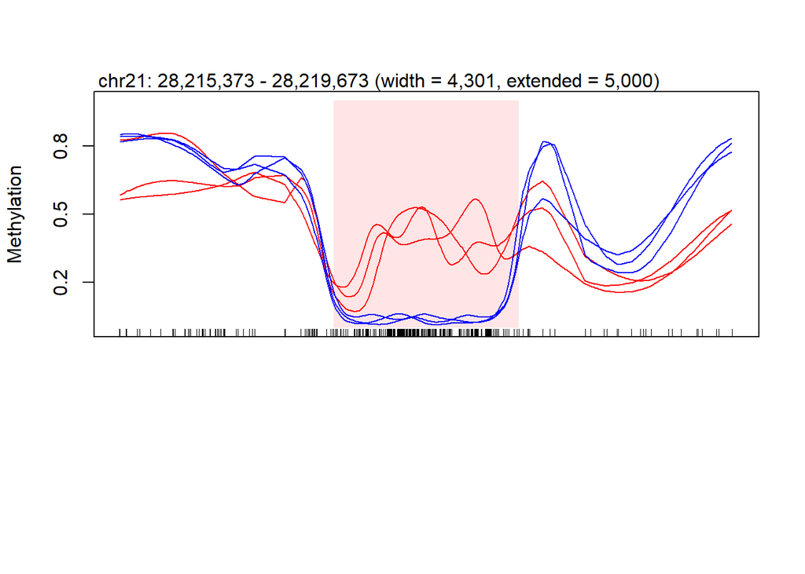

```r
plotRegion(BS.cancer.ex.fit, dmrs[1,], extend = 5000, addRegions = dmrs)
```

extend tells us how many bp to extend to either side of the plotting region. addRegions is a data.frame or GRanges listing additional regions that should be highlighted.

```r
pdf(file = "dmrs_top200.pdf", width = 10, height = 5)
plotManyRegions(BS.cancer.ex.fit, dmrs[1:200,], extend = 5000,
                addRegions = dmrs)
```

[output not shown]

[output not shown]

[output not shown]

[output not shown]

[output not shown]

[output not shown]

[output not shown]

[output not shown]

[output not shown]

[output not shown]

[output not shown]

[output not shown]

[output not shown]

[output not shown]

[output not shown]

[output not shown]

[output not shown]

[output not shown]

[output not shown]

[output not shown]

[output not shown]

[output not shown]

[output not shown]

[output not shown]

[output not shown]

[output not shown]

[output not shown]

[output not shown]

[output not shown]

[output not shown]

[output not shown]

[output not shown]

[output not shown]

[output not shown]

[output not shown]

[output not shown]

[output not shown]

[output not shown]

[output not shown]

[output not shown]

[output not shown]

[output not shown]

[output not shown]

[output not shown]

[output not shown]

[output not shown]

[output not shown]

[output not shown]

[output not shown]

[output not shown]

[output not shown]

[output not shown]

[output not shown]

[output not shown]

[output not shown]

[output not shown]

[output not shown]

[output not shown]

[output not shown]

[output not shown]

[output not shown]

[output not shown]

[output not shown]

[output not shown]

[output not shown]

[output not shown]

[output not shown]

[output not shown]

[output not shown]

[output not shown]

[output not shown]

[output not shown]

[output not shown]

[output not shown]

[output not shown]

[output not shown]

[output not shown]

[output not shown]

[output not shown]

[output not shown]

[output not shown]

[output not shown]

[output not shown]

[output not shown]

[output not shown]

[output not shown]

[output not shown]

[output not shown]

[output not shown]

[output not shown]

[output not shown]

[output not shown]

[output not shown]

[output not shown]

[output not shown]

[output not shown]

[output not shown]

[output not shown]

[output not shown]

[output not shown]

[output not shown]

[output not shown]

[output not shown]

[output not shown]

[output not shown]

[output not shown]

[output not shown]

[output not shown]

[output not shown]

[output not shown]

[output not shown]

[output not shown]

[output not shown]

[output not shown]

[output not shown]

[output not shown]

[output not shown]

[output not shown]

[output not shown]

[output not shown]

[output not shown]

[output not shown]

[output not shown]

[output not shown]

[output not shown]

[output not shown]

[output not shown]

[output not shown]

[output not shown]

[output not shown]

[output not shown]

[output not shown]

[output not shown]

[output not shown]

[output not shown]

[output not shown]

[output not shown]

[output not shown]

[output not shown]

[output not shown]

[output not shown]

[output not shown]

[output not shown]

[output not shown]

[output not shown]

[output not shown]

[output not shown]

[output not shown]

[output not shown]

[output not shown]

[output not shown]

[output not shown]

[output not shown]

[output not shown]

[output not shown]

[output not shown]

[output not shown]

[output not shown]

[output not shown]

[output not shown]

[output not shown]

[output not shown]

[output not shown]

[output not shown]

[output not shown]

[output not shown]

[output not shown]

[output not shown]

[output not shown]

[output not shown]

[output not shown]

[output not shown]

[output not shown]

[output not shown]

[output not shown]

[output not shown]

[output not shown]

[output not shown]

[output not shown]

[output not shown]

[output not shown]

[output not shown]

[output not shown]

[output not shown]

[output not shown]

[output not shown]

[output not shown]

[output not shown]

[output not shown]

[output not shown]

[output not shown]

[output not shown]

[output not shown]

[output not shown]

[output not shown]

[output not shown]

[output not shown]

[output not shown]

[output not shown]

[output not shown]

```r
dev.off()
```

which plots the top200.

# 6 Question and answers

The BSmooth algorithm is supposed to give smooth methylation estimates. Yet, when I plot the smoothed values, I see jagged lines, which do not look smooth to me.

We estimate a genome-wide methylation profile that is a smooth function of the genomic position. However, this profile is not stored in the BSseq objects. Instead, we evaluate this smooth profile in the methylation loci in the object. An example (made-up values) is

pos meth 1 0.1 3 0.1 5 0.1 200 0.6 203 0.6 205 0.6

For plotting we do linear interpolation between this points. The end result is that the methylation profile may appear jagged especially if there is a “big” distance between two CpGs (between pos 5 and 200 above). If we wanted to plot truly smooth profiles we would have to store the methylation profile evaluated at a regular grid across the genome. This takes up a lot of space and would add complications to the internal data structures.

# 8 References

Hansen, Kasper D, Benjamin Langmead, and Rafael A Irizarry. 2012. “BSmooth: from whole genome bisulfite sequencing reads to differentially methylated regions.” Genome Biology 13 (10): R83. https://doi.org/10.1186/gb-2012-13-10-r83.

Hansen, Kasper D, Winston Timp, Hector Corrada Bravo, Sarven Sabunciyan, Benjamin Langmead, Oliver G. McDonald, Bo Wen, et al. 2011. “Generalized Loss of Stability of Epigenetic Domains Across Cancer Types.” Nature Genetics 43 (8): 768–75. https://doi.org/10.1038/ng.865.